# DS250 - Introduction to Data Science

Kevin Niemann

November 3, 2015

# Assignment 5 - Core concepts in Statistics

This assignment covers core concepts in data and descriptive and inferential statistics. Statistical analysis is one of the primary tools of a Data Scientist used in understanding data, testing validity, and making predictions.

### The objectives of this assignment are:

- Understand the types of data
- Review core concepts in descriptive statistics
- High level review of probability distributions
- Practice making predictions using regression and probability

#### Question 1 - Types of Data

**a**. Describe some of the differences between qualitative and quantitative data:

```
Quantitative data can be measured numerically, may be considered objective. Qualitative is a description of something. This could be subjective.
```

**b**. Describe some of the differences between an interval and a ratio:

```
The main difference is that an interval of zero doesn't mean zero of that thing, versus a ratio of zero does.
```

- Mode: the value with the highest occurance.
- Median: the number that is halfway through a set.
- Mean: the sum of a set of numbers divided by the number of numbers (average).

**b**. Dispersion: Briefly describe the following measures:

- Range: the difference between the highest and lowest numbers in a set.
- Variance: the average of the squared distances from the mean.
- Standard deviation: The square root of the variance.

**c**. Using the following sequence, create a plot of the normal distribution with a mean = 0 and standard deviation = 1.

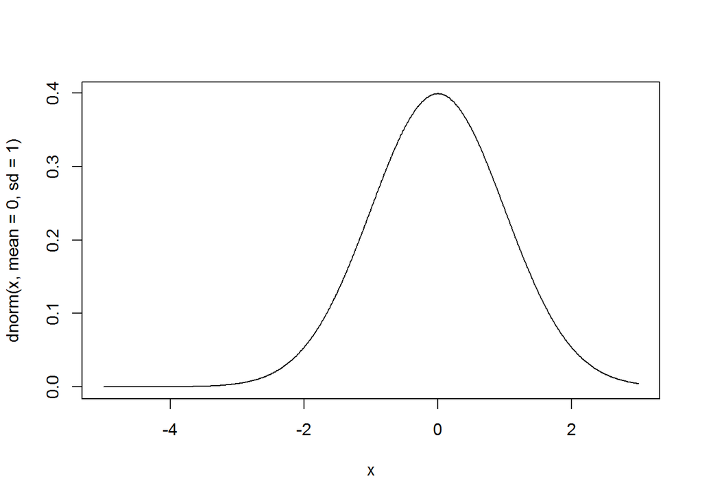

```r
x <- seq(-5,3, 0.01)
plot(x=x, y=dnorm(x, mean=0, sd=1), type='l')
```

#### Question 3 - Probabilities

**a**. Using the heart patient data in the ‘processed.cleveland.data.txt’ file: (link below)  
(https://archive.ics.uci.edu/ml/machine-learning-databases/heart-disease/heart-disease.names)  
(https://archive.ics.uci.edu/ml/machine-learning-databases/heart-disease/processed.cleveland.data)

- separate the population into male and female groups
- calculate the mean and standard deviation for male cholesterol values
- create a histogram showing the distribution of male cholesterol values

```r
heart <- read.table("https://archive.ics.uci.edu/ml/machine-learning-databases/heart-disease/processed.cleveland.data",sep=",",header=FALSE)
colnames(heart) <- c("age","sex","cp","trestbps","chol","fbs","restecg","thalach","exang","oldpeak","slope","ca","thal","num")
mheart <- subset(heart, heart$sex == 1)
fheart <- subset(heart, heart$sex == 0)
mean(mheart$chol)
```

```
## [1] 239.6019
```

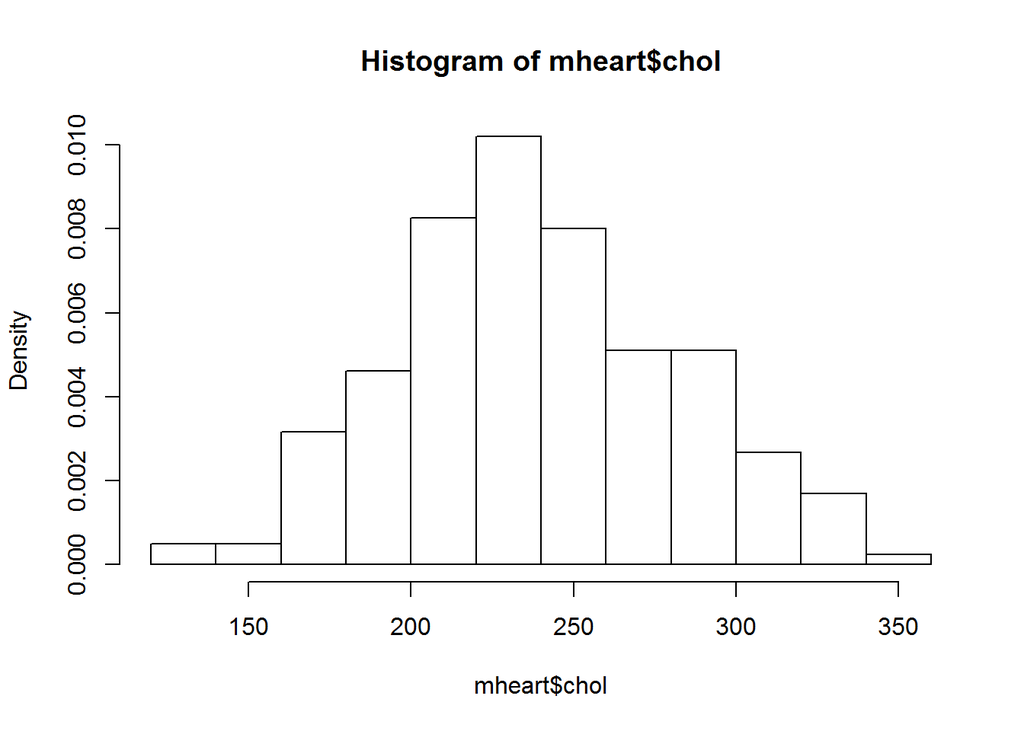

```r
hist(mheart$chol, probability = TRUE)
```

**b**. Using **rnorm()**, create a normal distribution and compare the histogram of the male cholesterol against the simulated normal distribution. Are they the same? *(can also use dnorm())*

```
mcholmean <- mean(mheart$chol)
mcholsd   <- sd(mheart$chol)
x <- 126:353
y <- rnorm(n=x, mean = mcholmean, sd = mcholsd)
hist(y,probability = TRUE)

Based on the histogram comparison, the data looks like a normal distribution.
```

**c**. Using **pnorm()**, determine the probability that a randomly chosen adult male has a cholesterol level of over 260.

```
1 - pnorm(q = 260, mean = mcholmean, sd = mcholsd)
.31
```

#### Question 4 - Comparison

**a**. Load sample data file from: (http://www.openintro.org/stat/data/cdc.R)  
*(use “source(file)” function to load external R data.)*

```
source("http://www.openintro.org/stat/data/cdc.R")
```

**b**. Create a histogram plot of the weight values:

```
hist(cdc$weight)
```

**c**. Create a new data frame (*young*) from the cdc data file containing individuals between the ages of (18 to 30).

```
young <- subset(cdc, age >= 18 & age <= 30)
```

**d**. Use **sample()**, to collect 50 random sample values from the (young) data frame.

```
sample <- young[sample(nrow(young), 50, replace = FALSE, prob = NULL),]
```

**e**. Describe the distribution of this sample?  
How does it compare to the distribution of the population from which it was sampled from?

```
cdcNum <- sapply(cdc, is.numeric)
colMeans(cdc[, cdcNum])

sampleNum <- sapply(sample, is.numeric)
colMeans(sample[, sampleNum])

Sample is taller, weighs less, smokes less.
```

**f**. Using **sample()**, create three separate sample collections for (10, 50, 100) samples and plot the histogram of these three data sets. How are they different?

*using the original cdc data, not the filtered ‘young’ data*

```
sample10 <- cdc[sample(nrow(cdc), 10, replace = FALSE, prob = NULL),]
hist(sample10$age)
sample50 <- cdc[sample(nrow(cdc), 50, replace = FALSE, prob = NULL),]
hist(sample50$age)
sample100 <- cdc[sample(nrow(cdc), 100, replace = FALSE, prob = NULL),]
hist(sample100$age)
```

#### Question 5 - Confidence Intervals

Using the sample data from: (http://www.openintro.org/stat/data/cdc.R)  
*(use “source()” to load an external file)*

**a**. Create a data frame with the height values from the cdc sample data.

```
height <- data.frame(cdc$height)
```

**b**. Create a sample data frame with 60 random samples of individual height values. Based on this sample data, what it the average height for these 60 individuals?

```
sample60 <- data.frame(height=height[sample(nrow(height), 60, replace = FALSE, prob = NULL),])
mean(sample60$height)
67.16
```

**c**. Calculate a confidence interval (upper, lower bounds) for the sample data.

```
t <- t.test(sample60$height)
t
```

**d**. Write a short loop to create (50) separate sample sets and calculate the confidence intervals for each set. How do the confidence intervals change in the 50 samples?

```
intervals <- list()
for (i in 1:50) {
   sampleset <- sample_n(height,60,replace=FALSE)
   intervals[[i]] <- t.test(sampleset)$conf.int
}

intervals.df <- as.data.frame(do.call(rbind, intervals))

ggplot(data = intervals.df) + geom_segment(aes(x = 1:50, xend = 1:50, y = V1, yend = V2))

The confidence intervals change randomly.
```

#### Question 6 - Inference

Use **“load()”** to import sample data file from: (http://www.openintro.org/stat/data/nc.RData) and complete the following:

**a**. Review the attributes in this data set and determine which ones are categorical or numeric.

```
load(url('http://www.openintro.org/stat/data/nc.RData'))
head(nc)
Numerical: fage,mage,weeks,visits,gained,weight
Categorical: mature,premie,martial,lowbirthweight,gender,habit,whitemom
```

**b**. Create a side-by-side boxplot of habit and weight. What does the plot highlight about the relationship between these two variables?

```
library(ggplot2)
data <- tbl_df(nc)
plot<-ggplot(data, aes(x=habit, y=weight))
plot+geom_boxplot()

Smokers kids weight less than non smoker kids at birth.
```

**c**. Using the following statement to compare weight and habit. Is the difference between the mean of nonsmoker and that of smoker statistically significant?

```
by(nc$weight, nc$habit, mean)

g1 <- tnc %>% filter(habit == 'smoker') %>% select(weight)
g2 <- tnc %>% filter(habit == 'nonsmoker') %>% select(weight)
t.test(g2$weight,g1$weight, paired=FALSE, var.equal=FALSE)$conf

Difference is statistically different.
```

**d**. Use the following statement to calculate the inference measure between weight and habit.

```
inference(y = nc$weight, x = nc$habit, est = "mean", type = "ht", null = 0, alternative = "twosided", method = "theoretical")

Response variable: numerical, Explanatory variable: categorical
Difference between two means
Summary statistics:
n_nonsmoker = 873, mean_nonsmoker = 7.1443, sd_nonsmoker = 1.5187
n_smoker = 126, mean_smoker = 6.8287, sd_smoker = 1.3862
Observed difference between means (nonsmoker-smoker) = 0.3155

H0: mu_nonsmoker - mu_smoker = 0
HA: mu_nonsmoker - mu_smoker != 0
Standard error = 0.134
Test statistic: Z =  2.359
p-value =  0.0184
```

**e**. In the statement above, change the type argument to ‘ci’ to construct a confidence interval for the difference between the weights of babies born to smoking and non-smoking mothers.

```
inference(y = nc$weight, x = nc$habit, est = "mean", type = "ci", null = 0, alternative = "twosided", method = "theoretical")
Response variable: numerical, Explanatory variable: categorical
Difference between two means
Summary statistics:
n_nonsmoker = 873, mean_nonsmoker = 7.1443, sd_nonsmoker = 1.5187
n_smoker = 126, mean_smoker = 6.8287, sd_smoker = 1.3862
Observed difference between means (nonsmoker-smoker) = 0.3155

Standard error = 0.1338
95 % Confidence interval = ( 0.0534 , 0.5777 )
```

#### Question 7 - Linear Regression

Load the sample data file from: (http://www.openintro.org/stat/data/mlb11.RData) and complete the following:

**a**. Use the **cor()** function to determine the numeric relationship between ‘runs’ and ‘at_bats’.

```
load(url('http://www.openintro.org/stat/data/mlb11.RData'))

cor(x=mlb11$at_bats,y=mlb11$runs)
```

**b**. Use the custom function **plot_ss()** *(included in RData file)* to create a plot for:

```
plot_ss(x = mlb11$at_bats, y = mlb11$runs, showSquares = TRUE)
```

**c**. Review the mlb11 data set and select another variable that might be a good predictor of runs.

```
cor(x=mlb11$new_onbase,y=mlb11$runs)
On base (percentage of time a batter gets to a base)
```

**d**. Create a scatterplot of the two variables and fit a linear model. Determine if there is a linear relationship?

```
plot <- ggplot(mlb11, aes(new_onbase, runs))
plot + geom_smooth(method=lm)

mlb11.lm <- lm(formula = runs ~ new_onbase, data = mlb11)
summary(mlb11.lm)
```

P value is very small so there is definitely a linear relationship.

#### Question 8 - Linear Regression

Use the built-in dataset (*faithful*) and complete the following:

1. Create a linear model *lm()* and capture the standard residuals :

```
data(faithful)

faithlm <- lm(eruptions ~ waiting, data=faithful)
faithresid = rstandard(faithlm)
summary(faithlm)
```

2. Using *qqnorm()* create a normal probability plot with *qqline()* showing the comparison:

```
qqnorm(faithresid, ylab="Residuals", xlab="Score", main="Faithful eruptions")

qqline(faithresid)
```